# Lecture 14 - Theory and Task for Homework with Solution

This is an [R Markdown](http://rmarkdown.rstudio.com) Notebook

### Lecture 14 - Using inputs in the ShinyApp

#### Basic idea of using inputs

The overall idea of using `inputs` from the User Interface is to define them first in ui.R file as `inputId` objects and use them in server.R file as `input$inputId` for example:

```r
# Defined in the ui.R:
dateInput(inputId = "DateStart", label = "Insert Start Date", value = "2017-01-01")

# Used in server.R as:
  # create reactive object
  StartDate <- reactive( {as.POSIXct(input$DateStart)} )
  # or simply
  input$DateStart
```

in case of creation of reactive objects we can re-use them by adding `()` to the object name, for example:

```r
# using reactive value further in the code
 filter(StartDateTime > StartDate())
```

obviously if you will use your input value only once you can do the same by:

```r
# using reactive value further in the code
 filter(StartDateTime > input$DateStart)
```

#### Modularise your code

You can create reactive objects using `reactive` function. Advantage is that:

- you can perform data manipulation inside this reactive function
- result of manipulation will be kept in the memory
- you can modularise your code by reusing obtained result several times later in your code

For example, we perform complex manipulations and filtering as follows:

```r
# Creating reactive object inside reactive function
    # save as data frame data used for statistics in other render functions
  DF_SUM <- reactive({

    DF_TEMP %>%
      # filters for categories
      filter(EventText == input$selInput) %>%
      # group by
      group_by(Name) %>%
      # filters X date
      filter(StartDateTime > StartDate(), StartDateTime < EndDate())
  })

# Object DF_SUM() can be accessed later in the script...

  output$Plot2 <- renderPlot({
    # generate object for the plot using DF_SUM
    DF_SUM() %>%
      ggplot(aes(x = StartDateTime, y = TimeTotal, col = EventText)) + geom_boxplot() +
      facet_wrap(Name ~ EventText) +
      ggtitle(paste("Overview of Steps ", "from: ",
                                      StartDate(), " to: ", EndDate(), sep = ""))
```

#### Debugging / develop your code modules

Once creating your `server.R` script you will inevitably need to try our what you will get. My personal hint is to try pieces of code using pre-defined `dummy` variables that you can comment inside your code. For example:

```r
# Un comment this code for debugging...
  # uncomment for debugging...
  StartDate <- "2017-04-20 00:10:20"
  EndDate <- "2017-08-20 00:10:20"

# ... and temporary remove brackets
 DF_SUM %>%
      ggplot(aes(x = StartDateTime, y = TimeTotal, col = EventText)) + geom_boxplot() +
      facet_wrap(Name ~ EventText) +
      ggtitle(paste("Overview of Steps ", "from: ",
                                      StartDate, " to: ", EndDate, sep = ""))
```

Then you can execute this code by pressing **CTRL + Enter** or **CMD + Enter** on Mac and verify the result in the Environment or as a Plot output result…

### Using buttons to delay reactions

```r
# in ui.R: Generate actionButton with inputId = "updateGraph"
actionButton(inputId = "updateGraph", label = "Update Graphs")

# in server.R: create snippet module with eventReactive(input$inputId{ code })
 delayReaction <- eventReactive(input$updateGraph, {

     # place the code here that will be run when button is clicked
    DF_SUM() %>%
        ggplot(aes(x = StartDateTime, y = TimeTotal, col = EventText)) +
        geom_smooth(alpha = 0.5, se = StatErr()) +
        facet_wrap(~Name) + ylab("Duration of Step, seconds") +
        ggtitle(paste("Overview of Steps ", "from: ",
                                        StartDate(), " to: ", EndDate(), sep = ""))
  })

  # finally create the output using delayReaction() object!
  output$Plot1 <- renderPlot({   delayReaction() })
```

### Some ideas for practical work

#### Debug your code in Shiny server.R file

Snippet of code below was taken directly from the `server.R` script. Use some `dummy` variables to verify your code inside `reactive` function that builds `DF_SUM`. Make sure that filter functions are properly working…

Hint: create another `dummy` variable give it the value `"Step 2 SubStep 6"`. Use it instead of `input$selInput`

```r
############# Run this code to create object DF_TEMP

# data frame containing information from multiple sensors
DF_Data <- read_csv("DF_Data.csv")
# data frame containing equipment information
DF_Equipm <- read_csv("DF_EquipmData.csv")
# data frame containing Event Names
DF_EvCode <- read_csv("DF_EvCodeData.csv")

# Data manipulation and saving to the DF_TEMP
DF_TEMP <- DF_Data %>%
  # arrange by date
  arrange(StartDateTime) %>%
  # join to decode equipment serial number
  inner_join(DF_Equipm, by = "IDEquipment") %>%
  # select only column needed
  select(StartDateTime, Name, EventCode, TimeTotal) %>%
  # join to decode Event Code meaning
  inner_join(DF_EvCode, by = "EventCode") %>%
  # select only column needed
  select(StartDateTime, Name, EventCode, TimeTotal, EventText)
#############

 # # uncomment below code for debugging...
  StartDate <- "2017-04-20 00:10:20"
  EndDate <- "2017-08-20 00:10:20"
  Step <- "Step 2 SubStep 6"
  #StatErr <- FALSE

############ Modify this code below to be able to run the code inside

 DF_SUM <- reactive({

  # run this code manually
    DF_TEMP %>%
      # filters for categories //replace input$... with a string...
      filter(EventText == Step) %>%
      # group by
      group_by(Name) %>%
      # filters X date
      filter(StartDateTime > StartDate, StartDateTime < EndDate)

      # chunk can be now selected and executed with CTRL + ENTER

  })
```

```
## Source: local data frame [6 x 5]
## Groups: Name [4]
##
##         StartDateTime       Name EventCode TimeTotal        EventText
##                <time>      <chr>     <int>     <int>            <chr>
## 1 2017-04-21 06:21:00 Machine #3 103007350      1169 Step 2 SubStep 6
## 2 2017-04-21 06:23:30 Machine #1 103007350      1079 Step 2 SubStep 6
## 3 2017-04-21 06:24:52 Machine #2 103007350       998 Step 2 SubStep 6
## 4 2017-04-21 09:24:10 Machine #4 103007350       580 Step 2 SubStep 6
## 5 2017-04-22 15:52:10 Machine #1 103007350      1112 Step 2 SubStep 6
## 6 2017-04-22 15:57:06 Machine #2 103007350       963 Step 2 SubStep 6
```

#### use buttons in your ShinyApp

This practical excercise will allow you to practice skills to create action button with `inputId = "updateGraph"` as well as to execute code in Shiny only after this button was pressed

Try to add new `button` to the right of the `selectInput` field…

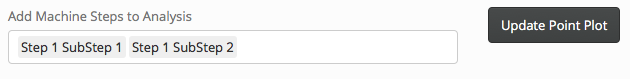

```r
# create new action button in ui.R
column(1, actionButton(inputId = "updateGraph", label = "Update Point Plot"))
```

… make sure that the `Plot-Points` is only updated once user pressing the new button?

Hint: use `delayed <- eventReactive(input$<inputId>, { code })`

```r
  ## creating eventReactive using new button
  updateGraph <- eventReactive(input$updateGraph,
    {
      DF_SUM()  %>%
            ggplot(aes(x = StartDateTime, y = TimeTotal, col = EventText)) + geom_point()+
            geom_smooth(alpha = 0.5, se = StatErr()) +
            facet_wrap(~Name) +
            ylab("Duration of Step, seconds") +
            ggtitle(paste("Overview of Steps ", "from: ",
                                            StartDate(), " to: ", EndDate(), sep = ""))

    })
```

Hint: use `delayed()` object when creating `output$'object'`

```r
 ## make a plot
  output$Plot1 <- renderPlot({ updateGraph() })
```